# GerminaQuant for R

Flavio Lozano Isla

Omar Benites Alfaro

Marcelo Francisco Pompelli

09 janeiro 2017

# Introduction

[figure not shown]

**GerminaQuant** allows make the calculation of the germination variables incredibly easy in an interactive applications build in R (R Core Team 2016), based in GerminaR and Shiny (Chang et al. 2016) package. GerminaQuant app is reactive!. Outputs change instantly as users modify inputs, without requiring a reload the app. The principal features of the application allow calculate the princiapal germination Variables, statistical analysis and easy way to plot the results.

[figure not shown]

[figure not shown]

# 1 Evaluation of the seed germination process

The physiology and seed technology have provided valuable tools for the production of high quality seed and treatments and storage conditions (Marcos-Filho 1998). In basic research, the seeds are studied exhaustively, and the approach of its biology is performed to fully exploit the dormancy and germination (Penfield and King 2009). An important tool for indicate the performance of a seed lot is the precise quantification of germination through accurate analysis of the cumulative germination data (Joosen et al. 2010). Time, velocity, homogeneity, uncertainty and synchrony are measurements that inform the dynamics of the germination process. It is interesting not only for physiologists and seed technologists, but also for environmentalists, since it is possible to predict the degree of success of the species, based on the seed crop ability to redistribute germination over time, allowing the recruitment of part of the seedlings formed (Ranal and Santana 2006).

# 2 Germination variables

## 2.1 Germinability (G)

According to L. G. Labouriau (1983a), germinability is the percentage of seeds in which the germination process comes to the end in the experimental conditions by the intraseminal growth, resulting in the protrusion (or emergence) of a living embryo.

$$g=\left(\frac{\sum_{i=1}^kn_1}{N}\right)100 \\ (in\ percentage;\ expressed\ in\ the\ program\ as\ GRP)$$

**Where:** $n_i$: number of germinated seed in the $i^{th}$ time; N: total number of seed in each experimental unit.

## 2.2 Mean Germination Time (t) and Standard Deviation (S<sub>t</sub>)

The mean germination time was proposed by Haberlandt in 1875 (L. G. Labouriau 1983a) and used by Czabator (1962) as mean length of incubation time (see Ranal and Santana (2006) for other details). It is calculated as the weighted mean of the germination time (hour, day or other time unit). The number of germinated seeds at the intervals established for the data collection is used as weight (Ranal and Santana 2006).

$$\overline{t}=\frac{\sum_{i=1}^kn_it_i}{\sum_{i=1}^kn_i} \\ (in\ hour,\ day\ or\ other\ time\ unit; \ expressed\ in\ the\ program\ as\ MGT)$$

$$S_t=\sqrt{\left\{\frac{\left\{\sum_{_{i=1}}^kn_i\left(t_i-\overline{t}\right)^2\right\}}{\sum_{_{i=1}}^kn_i-1}\right\}} \\ (in\ the\ same\ time\ unit\ of\ the\ mean\ germination\ time;\ expressed\ in\ the\ program\ as\ SDG)$$

**Where** $\bar{t}_i$: time from the start of the experiment to the $i^{th}$ observation (hour, day or other time unit); $n_i$: number of germinated seeds in the $i^{th}$ time (not the accumulated number) and $k$: the last time of observation.

## 2.4 Mean Germination Rate (v)

The mean germination rate is defined as the reciprocal of the mean germination time, since the mean germination rate increases and decreases with $\frac{1}{\overline{t}}$, not with $\overline{t}$ (L. G. Labouriau 1983b).

$$\overline{v}=\frac{1}{\overline{t}} \\ \left(in\ hours^{-1},\ day^{-1}\ or\ other\ reciprocal\ time\ unit,\ \exp ressed\ in\ the\ program\ as\ MGR\right)$$

## 2.5 Uncertainty Index (U)

This measurement is an adaptation of the Shannon index and measures the degree of uncertainty associated to the distribution of the relative frequency of germination (Labouriau and Valadares 1976). Low values indicate more synchronized germination (Ranal and Santana 2006).

$$U\ =\ -\sum_{i=1}^kf_i\log_2f_i\ \\ \left(in\ bit;\ \exp ressed\ in\ the\ program\ as\ UNC\right),\ being\ f_i=\frac{n_i}{\sum_{i=1}^kn_i}$$

**Where** $f_i$: relative frequency of germination; $n_i$: number of seed germinated in the $i^{th}$ time, and $k$: the last day of germination.

## 2.6 Synchronyzation Index (Z)

This index was proposed by Primack (1985) to assess the degree of overlapping of flowering among individuals in a population and Ranal and Santana (2006) adopted it for seed germination. The synchrony of germination of one seed with another assumed $Z=1$ when the germination of all seeds occur at the same time and $Z = 0$ when at least two seeds can germinate, one at each time.

$$Z=\frac{\sum_{ }^{ }C_{n_1,2}}{N} \\ \left(a\dim ensional\ measurement;\ expressed\ in\ the\ program\ as\ SYN\right); \\ being\ C_{n_1,2}=\frac{n_i\left(n_i-1\right)}{2}\ ;\ N=\frac{\sum_{ }^{ }n_i\left(\sum_{ }^{ }n_i-1\right)}{2}$$

**Where** $C_{n_i,2}$: combination of germinated seeds in $i^{th}$ time, two together, and $n_i$: number of germinated seed in the $i^{th}$.

## 2.7 Limits and units of the germination variables in GerminaQuant

Table 2.1: Germination variables evaluated in GerminaQuant and limits according Ranal and Santana (2006) ; where: $n_i$, number of seed germinated in $i^{nth}$ time ; $K$, the last day of the avaliation process for germination.

[output not shown]

# 3 Germination field book

For correct analysis and fast data processing is important to take into account that the data organization and the correct data collection of the germination process is essential. In this section, we going to explain how can you collect and organize your data.

For data example and layout, you can access and download GerminaQuant [spreadsheet](https://docs.google.com/spreadsheets/d/1QziIXGOwb8cl3GaARJq6Ez6aU7vND_UHKJnFcAKx0VI/edit#gid=667855537).

## 3.1 Data Organization

The field book should have three essential parts. The treatment column (red), according to the experimental design (1); the seed number column (green) (2), and the observation moment column (blue) (3). In the green column you will indicate the number of seeds sown in each experimental unit and in the blue columns the germination values (Figure 3.1). You can design your own field book with different names in the column.

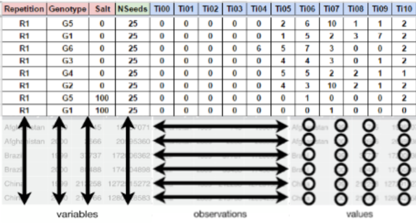

Figure 3.1: Layout for germination evaluation process. The factor column (red) are according the experimental design. The seed number column (green) for the number of seed sown and the evaluation columns (blue) are for accounting the germination.

## 3.2 Data Collection

The evaluation of the germination process is obtained of the count of the germination in each experimental unit and It can be evaluated in time lapse of hours, days or months in continuous interval of the same length always beginning with the time zero (ei. Ti00), until the end of the germination process or according to the researcher criteria

# 4 Germination analysis

After the data collection, the information can be processed using GerminaQuant App. The web application can be used in any device, connected to the internet, in an interactive way. The application is compound in tabs (Table 4.1) that allow to make the analysis very easy.

Table 4.1: Name and description of each tab of GerminaQuant to evaluate and analyze the germination process

| Tabs | Description |
| --- | --- |
| Introduction | Presentation of GerminaQuant and description of the germination variables |
| Data Import | Allow to upload the fieldbook, visualize all the data and chose the parameter for the analysis . |
| Germination Analysis | Calculate automatically the germination variables and export the data file. |
| Statisdtical Analysis | Allow to chose the variables according the experimental design for analysis of variance and summarise the information |
| Multi Plot | Plot the mean comparison test for the variables selected in diffrente plots: bar, line and boxplot. |
| Germination in Time | Selecting the treatment, allows plotting the germination process. |

# 5 GerminaQuant data processing

## 5.1 Field Book

For using the GerminaQuant is necessary that you have a data with germination values. You can use a following data [sample](https://docs.google.com/spreadsheets/d/1QziIXGOwb8cl3GaARJq6Ez6aU7vND_UHKJnFcAKx0VI/edit#gid=667855537). Open the link and download the data in csv format.

Files >> Download >> Comma Separated Values (.csv, current sheet) >> “GerminaQuant - Sample.csv”

If you have a google account you can clone the document for you and edit it online and download for your own analysis.

## 5.2 Import Data

When you have your field book, you can go [GerminaQuant](https://flavjack.shinyapps.io/germinaquant/) and go “Data Import” tab. Figure 5.1.

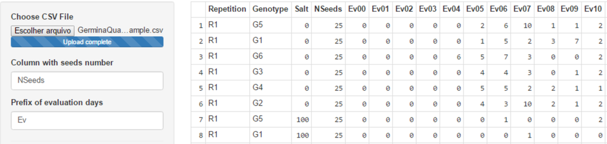

Figure 5.1: Data Import

Choose the file in “csv” format it will be analysed. In “Column with seeds number” you have to write the name of the column containing the information of the number of seed sown in each experimental unit, “Prefix of evaluation days” you have to put the prefix of the name called for the day for evaluate the germination time lapse.

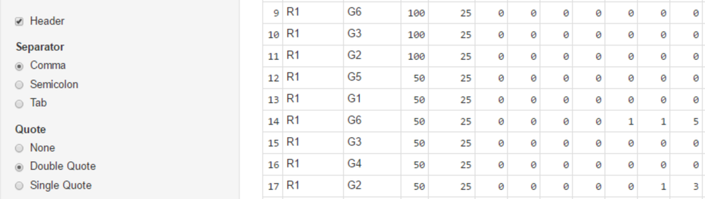

Figure 5.2: Table option for csv format

Below of the parameter for evaluation, you will find the option to select the parameter for the “csv” format file. In such way the file should have a table form. Figure 5.2

## 5.3 Indices calculation

If the parameter in the “Import Data” tab are correct, in “Germination analysis” tab will be performed and the values of the germination variables for each experimental unit will be show. Table 2.1. GerminaQuant app allows downloading the file in “csv” format with the calculation of the germination variables. Figure 5.3

[figure not shown]

Figure 5.3: Dowload option for the calculated variables

## 5.4 Statistical analysis

In this tab, the app perform a factorial variance analysis, calculate the statistical description of the factor, the mean differences through Student Newman Keuls (de Mendiburu 2016) and made the graphics (Wickham and Chang 2016) for the chosen variable.

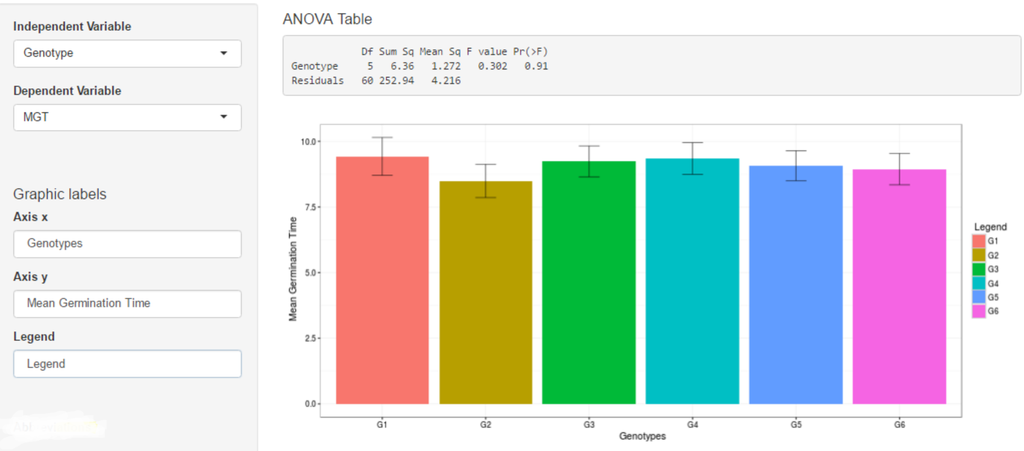

Figure 5.4: Statitical analysis with ANOVA and mean comparison test

Remember, the independent variables will be the factor in your field book and the dependent variable will be any of the germination variables. Automatically the app will generate the graphs for the variable chosen and give the mean comparison test. The axis label can be edited manually filling the case in the “Graphics labels” section. The bar and line graphs are represented by the mean and central line is the standard error.

## 5.5 Germination in Time

This Tab allows to visualize the germination process included in the field book. Figure 5.5

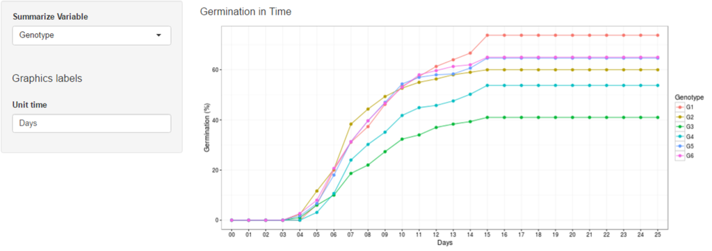

Figure 5.5: Germination in time plot

# References

Chang, Winston, Joe Cheng, JJ Allaire, Yihui Xie, and Jonathan McPherson. 2016. *Shiny: Web Application Framework for R*. https://CRAN.R-project.org/package=shiny.

Czabator, Felix J. 1962. “Germination value: an index combining speed and completeness of pine seed germination.” *Forest Science* 8 (4). Society of American Foresters: 386–96.

de Mendiburu, Felipe. 2016. *Agricolae: Statistical Procedures for Agricultural Research*. https://CRAN.R-project.org/package=agricolae.

Joosen, Ronny V. L., Jan Kodde, Leo A. J. Willems, Wilco Ligterink, Linus H. W. van der Plas, and Henk W.M. Hilhorst. 2010. “germinator : a software package for high-throughput scoring and curve fitting of Arabidopsis seed germination.” *The Plant Journal* 62 (1): 148–59. doi:10.1111/j.1365-313X.2009.04116.x.

Labouriau, L G. 1983a. *A germinacâo das sementes*. Washington.

———. 1983b. “Uma Nova Linha de Pesquisa Na Fisiologia Da Germinacao Das Sementes.” *In Anais do XXXIV Congresso Nacional de Botanica*.

Labouriau, LG, and MB Valadares. 1976. “On the Physiology of Seed of Calotropis Procera. Anais Da Academia Brasileira de Ciência.” *Rio de Janeiro* 42 (2): 235–64.

Marcos-Filho, J. 1998. “New approaches to seed vigor testing.” *Scientia Agricola* 55. Scientia Agricola: 27–33. doi:10.1590/S0103-90161998000500005.

Penfield, Steven, and John King. 2009. “Towards a systems biology approach to understanding seed dormancy and germination.” *Proceedings. Biological Sciences / The Royal Society* 276 (1673). doi:10.1098/rspb.2009.0592.

Primack, Richard B. 1985. “Patterns of Flowering Phenology in Communities, Populations, Individuals, and Single Flowers.” In *The Population Structure of Vegetation*, 571–93. Springer.

R Core Team. 2016. *R: A Language and Environment for Statistical Computing*. Vienna, Austria: R Foundation for Statistical Computing. https://www.R-project.org/.

Ranal, Marli A., and Denise Garcia de Santana. 2006. “How and why to measure the germination process?” *Revista Brasileira de Botânica* 29 (1). Sociedade Botânica de São Paulo: 1–11. doi:10.1590/S0100-84042006000100002.

Wickham, Hadley, and Winston Chang. 2016. *Ggplot2: Create Elegant Data Visualisations Using the Grammar of Graphics*. https://CRAN.R-project.org/package=ggplot2.